# Produção Italiana de Alimentos e Bebidas: Uma Análise Estatística da Série Histórica (1871–1985)

CE302 — Elementos de Programação para Estatística

Autores

Afiliação

Eduardo Lemos de Sá

Departamento de Estatística, UFPR

Emanuelle Maia Peclat

Departamento de Estatística, UFPR

Emily Yamagutti Watanabe

Departamento de Estatística, UFPR

Kelly Huang

Departamento de Estatística, UFPR

Shirley Espejo

Departamento de Estatística, UFPR

Data de Publicação

27/11/2026

# 1 Introdução e Contextualização (Shirley)

## 1.1 Alimentos e Bebidas (Emily)

A análise de séries históricas de produção permite compreender como setores econômicos evoluíram ao longo do tempo e como eventos de grande escala, como as guerras mundiais, afetaram a oferta ou causaram a diminuição da produção. O presente trabalho propõe uma análise estatística exploratória dos dados históricos do setor de alimentos e bebidas da Itália, no período de 1871 a 1985, com o objetivo de evidenciar a evolução temporal da produção ou do consumo ao longo de mais de um século, identificando padrões estruturais, impactos de eventos históricos, correlações entre insumos e mudanças de comportamento econômico.

O conjunto de dados abrange sete produtos: açúcar, glicose, substituto para café, óleo de sementes, álcool etílico 1, álcool etílico 2 e cerveja. Devido à extensão histórica da base, observa-se uma quantidade significativa de valores ausentes (NAs), característica comum em registros antigos.

Os objetivos específicos desta análise são:

- Descrever as características principais do conjunto de dados por meio de estatísticas descritivas por década e por produto;
- Comparar a evolução dos produtos entre si, identificando quais tendem a caminhar juntos ou a divergir;
- Avaliar o comportamento das séries nos períodos da 1ª Guerra Mundial (1914–1918) e da 2ª Guerra Mundial (1939–1945), comparando os cenários pré, durante e pós-guerra.

Este relatório está organizado da seguinte forma: a Seção 2 descreve os dados e os métodos utilizados; a Seção 3 apresenta os resultados e as discussões; e a Seção 4 sintetiza os principais achados.

## 1.2 Têxtil (Kelly)

## 1.3 Meios de transporte (Manu)

## 1.4 Análise do período da 1ª e 2ª Guerra Mundial (Eduardo)

# 2 Materiais e Métodos

## 2.1 Conjunto de Dados

Os dados são provenientes do projeto *TidyTuesday* (*R for Data Science Online Learning Community*), semana de 05/05/2026, e foram lidos diretamente do repositório do projeto no GitHub. Esses dados foram obtidos do site https://www.istat.it/ e pertencem ao ISTAT (sigla em inglês para *Italian National Institute of Statistics*), que é a principal fonte de dados estatísticos oficiais da Itália.

**Ver código**

```r
food_beverages <- readr::read_csv(
  "https://raw.githubusercontent.com/rfordatascience/tidytuesday/main/data/2026/2026-05-05/food_beverages.csv",
  show_col_types = FALSE
)

# Visão geral
glimpse(food_beverages)
```

```
Rows: 115
Columns: 8
$ Year              <dbl> 1871, 1872, 1873, 1874, 1875, 1876, 1877, 1878, 1879…
$ Sugar             <dbl> NA, NA, NA, NA, NA, NA, 102, 170, 19, 102, 64, 192, …
$ Glucose           <dbl> NA, NA, NA, NA, NA, NA, NA, NA, NA, NA, NA, NA, NA, …
$ Coffee_substitute <dbl> NA, NA, NA, 87, 2369, 5871, 6033, 5394, 5023, 5131, …
$ Seed_oil          <dbl> NA, NA, NA, NA, NA, NA, NA, NA, NA, NA, NA, NA, NA, …
$ Ethyl_alcohol_1   <dbl> 20817, 30059, 31744, 48540, 66191, 54321, 63906, 667…
$ Ethyl_alcohol_2   <dbl> NA, NA, NA, NA, NA, NA, NA, NA, 23383, 28158, 125811…
$ Beer              <dbl> NA, NA, NA, NA, NA, NA, NA, NA, 112329, 116217, 1273…
```

## 2.2 Pré-processamento

### 2.2.1 Pré-processamento de alimentos e bebidas

Para viabilizar a análise, foram realizadas as seguintes etapas de limpeza e organização:

- **Limpeza e padronização:** tradução dos nomes das variáveis para o português e conversão das unidades (glicose, substituto de café e óleo de sementes foram convertidos de quintais para toneladas, dividindo-se os valores por 10; cerveja e etanol permanecem em hectolitros);
- **Agrupamento por décadas:** classificação dos anos em intervalos de dez anos, para suavizar lacunas anuais e revelar tendências de longo prazo;
- **Estatística descritiva (excluindo NAs):** cálculo de soma, média, desvio padrão, mínimo, primeiro quartil (Q1), mediana, terceiro quartil (Q3) e máximo por década e por produto.

**Ver código**

```r
# Variáveis nas colunas do csv, usadas para renomear
variaveis_prod <- c(
  "Açúcar", "Glicose", "Substituto_café", "Oleo_de_sementes",
  "Etanol_1", "Etanol_2", "Cerveja"
)

# Paleta de cores
paleta_produtos <- c(
  "Açúcar"           = "#1b9e77",
  "Glicose"          = "#d95f02",
  "Substituto_café"  = "#7570b3",
  "Oleo_de_sementes" = "#e7298a",
  "Etanol_1"         = "#66a61e",
  "Etanol_2"         = "#e6ab02",
  "Cerveja"          = "#1f78b4"
)

# Tradução das colunas e conversão de unidades:
# Glicose, Substituto_café e Oleo_de_sementes: quintal -> toneladas (x / 10)
comidas_bebidas <- food_beverages |>
  rename(
    Ano = Year,
    Açúcar = Sugar,
    Glicose = Glucose,
    Substituto_café = Coffee_substitute,
    Oleo_de_sementes = Seed_oil,
    Etanol_1 = Ethyl_alcohol_1,
    Etanol_2 = Ethyl_alcohol_2,
    Cerveja = Beer
  ) |>
  mutate(
    across(c(Glicose, Substituto_café, Oleo_de_sementes), ~ .x / 10)
  )

# Transformar em formato longo (década e unidade de medida: hL ou t)
comidas_bebidas_longer <- comidas_bebidas |>
  pivot_longer(
    cols = all_of(variaveis_prod),
    names_to = "Variavel",
    values_to = "Valor"
  ) |>
  mutate(
    Decada  = paste0(floor(Ano / 10) * 10, "s"),
    unidade = if_else(str_detect(str_to_lower(Variavel), "cerveja|etanol"), "hL", "t")
  )

# Estatística descritiva por década e produto
cols_estat <- c("soma", "media", "dp", "min", "q1", "mediana", "q3", "max")

tabela_descritiva <- comidas_bebidas_longer |>
  group_by(Decada, Variavel) |>
  summarise(
    n_obs   = sum(!is.na(Valor)),
    n_na    = sum(is.na(Valor)),
    soma    = sum(Valor, na.rm = TRUE),
    media   = mean(Valor, na.rm = TRUE),
    dp      = sd(Valor, na.rm = TRUE),
    min     = suppressWarnings(min(Valor, na.rm = TRUE)),
    q1      = quantile(Valor, probs = 0.25, na.rm = TRUE, names = FALSE),
    mediana = median(Valor, na.rm = TRUE),
    q3      = quantile(Valor, probs = 0.75, na.rm = TRUE, names = FALSE),
    max     = suppressWarnings(max(Valor, na.rm = TRUE)),
    .groups = "drop"
  ) |>
  mutate(
    across(
      all_of(cols_estat),
      ~ if_else(is.nan(.x) | is.infinite(.x) | is.na(.x), NA_real_, .x)
    )
  ) |>
  arrange(Decada, Variavel)

# Funções e auxiliares
anos_min <- min(comidas_bebidas_longer$Ano, na.rm = TRUE)
anos_max <- max(comidas_bebidas_longer$Ano, na.rm = TRUE)
decadas  <- sort(unique(na.omit(comidas_bebidas_longer$Decada)))

fmt_br <- function(x) {
  ifelse(
    is.na(x) | !is.finite(x),
    "NA",
    formatC(x, format = "f", digits = 2, big.mark = ".", decimal.mark = ",")
  )
}

# Média e desvio padrão por década (usados no gráfico das guerras)
dados_decada <- comidas_bebidas_longer |>
  filter(!is.na(Decada), !is.na(Variavel), !is.na(Valor)) |>
  summarise(
    valor_decada = mean(Valor, na.rm = TRUE),
    dp_decada    = sd(Valor, na.rm = TRUE),
    n_obs        = n(),
    .by = c(Decada, Variavel)
  ) |>
  mutate(
    decada_num = as.numeric(sub("s$", "", Decada)),
    dp_decada  = coalesce(dp_decada, 0), # década com 1 observação: DP = 0
    inferior   = valor_decada - dp_decada,
    superior   = valor_decada + dp_decada
  ) |>
  arrange(Variavel, decada_num)
```

Após o tratamento, a base contém 115 anos (de 1871 a 1985, em 12 décadas) e 7 variáveis de produção. Cerca de 14.8% das células (119 de 805) são valores ausentes, que foram desconsiderados nos cálculos.

### 2.2.2 Técnicas Estatísticas

As análises realizadas neste trabalho incluem:

1. **Análise descritiva:** medidas de tendência central, dispersão e quartis por década e por produto;
2. **Visualização exploratória:** mapa de calor (R-bloggers, 2022; The R Graph Gallery, [*s. d.*]) para a comparação entre produtos e séries temporais com faixas sombreadas (Plotly, [*s. d.*]) para os períodos de guerra;
3. **Comparação pré, durante e pós-guerra:** avaliação das oscilações em torno das duas guerras mundiais.

As análises foram conduzidas no RStudio, com auxílio do pacote `tidyverse` (Wickham; Grolemund, 2017). Os mesmos cálculos e gráficos também foram implementados em um painel interativo (*dashboard*) com os pacotes `shinydashboard` (Chang; Borges Ribeiro, 2025; Posit / RStudio, [*s. d.*]) e `plotly` (Inc., 2015), e a escolha dos tipos de gráfico se apoiou em catálogos de visualização de dados, como o *Dataviz Project* (“100 Data Visualization Project”, [*s. d.*]).

# 3 Resultados e Discussão

## 3.1 Alimentos e Bebidas

Após a limpeza inicial dos dados, foi possível mapear o comportamento descritivo das séries (média, mediana, extremos, entre outras medidas) e comparar a dinâmica entre os produtos ao longo do tempo, inclusive durante os períodos das duas guerras mundiais.

### 3.1.1 Visão Geral e Estatística Descritiva

Esta etapa apresenta o panorama estrutural da base: a janela temporal de 1871 a 1985, as 7 variáveis avaliadas e a quantidade de valores ausentes. A Tabela 1 mostra os dados traduzidos e organizados retirados do *TidyTuesday*, e a Tabela 2 (*Estatística descritiva por década e produto*) apresenta as estatísticas descritivas dessas variáveis agrupadas por década.

**Ver código**

```r
comidas_bebidas |>
  head(10) |>
  mutate(across(all_of(variaveis_prod), fmt_br)) |>
  kbl(booktabs = TRUE, align = "r") |>
  kable_styling(
    bootstrap_options = c("striped", "hover", "condensed"),
    latex_options = c("striped", "scale_down"),
    full_width = FALSE
  )
```

Tabela 1: Base traduzida e convertida (toneladas e hectolitros) — primeiras 10 linhas.

| Ano | Açúcar | Glicose | Substituto_café | Oleo_de_sementes | Etanol_1 | Etanol_2 | Cerveja |
| --- | --- | --- | --- | --- | --- | --- | --- |
| 1871 | NA | NA | NA | NA | 20.817,00 | NA | NA |
| 1872 | NA | NA | NA | NA | 30.059,00 | NA | NA |
| 1873 | NA | NA | NA | NA | 31.744,00 | NA | NA |
| 1874 | NA | NA | 8,70 | NA | 48.540,00 | NA | NA |
| 1875 | NA | NA | 236,90 | NA | 66.191,00 | NA | NA |
| 1876 | NA | NA | 587,10 | NA | 54.321,00 | NA | NA |
| 1877 | 102,00 | NA | 603,30 | NA | 63.906,00 | NA | NA |
| 1878 | 170,00 | NA | 539,40 | NA | 66.799,00 | NA | NA |
| 1879 | 19,00 | NA | 502,30 | NA | 47.328,00 | 23.383,00 | 112.329,00 |
| 1880 | 102,00 | NA | 513,10 | NA | 111.474,00 | 28.158,00 | 116.217,00 |

**Ver código**

```r
tabela_descritiva |>
  mutate(across(all_of(cols_estat), fmt_br)) |>
  kbl(
    booktabs = TRUE, longtable = TRUE, align = "llrrrrrrrrrr",
    col.names = c("Década", "Variável", "N", "NAs", "Soma", "Média", "DP",
                  "Mín", "Q1", "Mediana", "Q3", "Máx")
  ) |>
  kable_styling(
    bootstrap_options = c("striped", "hover", "condensed"),
    latex_options = c("striped", "repeat_header"),
    font_size = 7,
    full_width = FALSE
  )
```

Tabela 2: Estatística descritiva por década e produto (NAs excluídos).

| Década | Variável | N | NAs | Soma | Média | DP | Mín | Q1 | Mediana | Q3 | Máx |
| --- | --- | --- | --- | --- | --- | --- | --- | --- | --- | --- | --- |
| 1870s | Açúcar | 3 | 6 | 291,00 | 97,00 | 75,62 | 19,00 | 60,50 | 102,00 | 136,00 | 170,00 |
| 1870s | Cerveja | 1 | 8 | 112.329,00 | 112.329,00 | NA | 112.329,00 | 112.329,00 | 112.329,00 | 112.329,00 | 112.329,00 |
| 1870s | Etanol_1 | 9 | 0 | 429.705,00 | 47.745,00 | 16.964,97 | 20.817,00 | 31.744,00 | 48.540,00 | 63.906,00 | 66.799,00 |
| 1870s | Etanol_2 | 1 | 8 | 23.383,00 | 23.383,00 | NA | 23.383,00 | 23.383,00 | 23.383,00 | 23.383,00 | 23.383,00 |
| 1870s | Glicose | 0 | 9 | 0,00 | NA | NA | NA | NA | NA | NA | NA |
| 1870s | Oleo_de_sementes | 0 | 9 | 0,00 | NA | NA | NA | NA | NA | NA | NA |
| 1870s | Substituto_café | 6 | 3 | 2.477,70 | 412,95 | 238,72 | 8,70 | 303,25 | 520,85 | 575,18 | 603,30 |
| 1880s | Açúcar | 10 | 0 | 3.004,00 | 300,40 | 231,32 | 64,00 | 138,00 | 188,00 | 424,50 | 722,00 |
| 1880s | Cerveja | 10 | 0 | 1.424.416,00 | 142.441,60 | 19.503,86 | 116.217,00 | 128.336,75 | 140.967,50 | 154.548,75 | 174.922,00 |
| 1880s | Etanol_1 | 10 | 0 | 1.580.929,00 | 158.092,90 | 62.213,75 | 31.926,00 | 114.453,50 | 185.248,00 | 199.624,25 | 232.146,00 |
| 1880s | Etanol_2 | 10 | 0 | 434.589,00 | 43.458,90 | 31.594,15 | 21.978,00 | 25.210,50 | 29.716,00 | 50.809,00 | 125.811,00 |
| 1880s | Glicose | 5 | 5 | 14.392,70 | 2.878,54 | 1.401,12 | 475,40 | 2.944,80 | 3.248,50 | 3.832,10 | 3.891,90 |
| 1880s | Oleo_de_sementes | 0 | 10 | 0,00 | NA | NA | NA | NA | NA | NA | NA |
| 1880s | Substituto_café | 10 | 0 | 12.372,80 | 1.237,28 | 736,42 | 355,80 | 463,23 | 1.418,10 | 1.929,45 | 2.020,20 |
| 1890s | Açúcar | 10 | 0 | 44.576,00 | 4.457,60 | 6.737,60 | 788,00 | 1.253,25 | 2.195,00 | 3.569,75 | 23.116,00 |
| 1890s | Cerveja | 10 | 0 | 1.186.201,00 | 118.620,10 | 21.751,95 | 93.856,00 | 101.134,25 | 112.180,50 | 132.623,00 | 156.224,00 |
| 1890s | Etanol_1 | 10 | 0 | 1.112.763,00 | 111.276,30 | 23.989,05 | 53.062,00 | 102.269,50 | 117.173,50 | 125.653,25 | 140.075,00 |
| 1890s | Etanol_2 | 10 | 0 | 779.638,00 | 77.963,80 | 33.909,09 | 51.528,00 | 57.557,50 | 63.375,50 | 81.369,00 | 155.642,00 |
| 1890s | Glicose | 10 | 0 | 30.718,30 | 3.071,83 | 414,30 | 2.553,20 | 2.833,12 | 3.037,00 | 3.291,90 | 3.869,90 |
| 1890s | Oleo_de_sementes | 0 | 10 | 0,00 | NA | NA | NA | NA | NA | NA | NA |
| 1890s | Substituto_café | 10 | 0 | 23.725,70 | 2.372,57 | 399,52 | 1.882,50 | 2.050,20 | 2.306,50 | 2.692,65 | 3.019,70 |
| 1900s | Açúcar | 10 | 0 | 1.051.447,00 | 105.144,70 | 31.937,64 | 60.125,00 | 82.264,75 | 100.896,00 | 125.844,50 | 165.312,00 |
| 1900s | Cerveja | 10 | 0 | 3.165.874,00 | 316.587,40 | 156.928,65 | 162.188,00 | 186.601,50 | 262.102,50 | 425.600,00 | 567.186,00 |
| 1900s | Etanol_1 | 10 | 0 | 1.497.416,00 | 149.741,60 | 25.931,76 | 101.370,00 | 132.738,00 | 157.289,50 | 162.881,50 | 194.286,00 |
| 1900s | Etanol_2 | 10 | 0 | 1.810.277,00 | 181.027,70 | 184.707,82 | 53.669,00 | 66.167,00 | 90.059,00 | 252.529,00 | 634.668,00 |
| 1900s | Glicose | 10 | 0 | 46.144,20 | 4.614,42 | 1.075,92 | 3.335,00 | 3.607,15 | 4.674,30 | 5.309,22 | 6.568,50 |
| 1900s | Oleo_de_sementes | 0 | 10 | 0,00 | NA | NA | NA | NA | NA | NA | NA |
| 1900s | Substituto_café | 10 | 0 | 37.833,20 | 3.783,32 | 609,64 | 3.111,40 | 3.204,45 | 3.678,65 | 4.308,45 | 4.795,40 |
| 1910s | Açúcar | 10 | 0 | 1.650.049,00 | 165.004,90 | 57.983,45 | 92.624,00 | 146.206,50 | 154.529,50 | 171.829,75 | 305.560,00 |
| 1910s | Cerveja | 10 | 0 | 6.255.169,00 | 625.516,90 | 144.834,80 | 411.344,00 | 543.779,50 | 609.830,00 | 667.749,00 | 949.102,00 |

[output cut: 54 more lines]

### 3.1.2 Comparação entre os Produtos e Períodos

Para investigar as relações entre as séries, o mapa de calor da Figura 1 mostra a média de cada produto por década (em escala `log1p`, pois os produtos têm magnitudes muito distintas). Ele evidencia quais produtos tendem a caminhar juntos, divergir ou apresentar comportamento independente. Células em branco indicam décadas sem dados para o produto.

**Ver código**

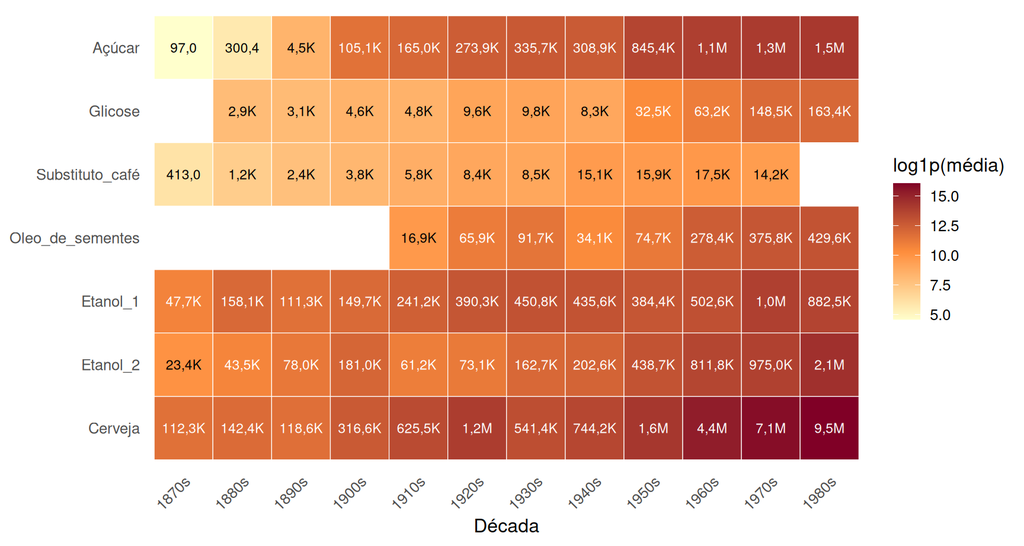

Figura 1: Média por década e produto. Cor em escala log1p da média; o texto indica a média.

```r
rotulo_curto <- label_number(accuracy = 0.1, scale_cut = cut_short_scale(),
                             decimal.mark = ",")

d_heat <- tabela_descritiva |>
  filter(!is.na(Decada)) |>
  mutate(
    Decada   = factor(Decada, levels = decadas),
    Variavel = factor(Variavel, levels = variaveis_prod),
    z        = log1p(media)
  )

z_meio <- mean(range(d_heat$z, na.rm = TRUE))

d_heat |>
  mutate(
    rotulo = if_else(is.na(media), "", rotulo_curto(media)),
    cor_tx = if_else(!is.na(z) & z > z_meio, "white", "black")
  ) |>
  ggplot(aes(x = Decada, y = fct_rev(Variavel), fill = z)) +
  geom_tile(colour = "white") +
  geom_text(aes(label = rotulo, colour = cor_tx), size = 3) +
  scale_colour_identity() +
  scale_fill_gradientn(colours = c("#ffffcc", "#fd8d3c", "#800026"),
                       name = "log1p(média)", na.value = "white") +
  labs(x = "Década", y = NULL) +
  theme(axis.text.x = element_text(angle = 45, hjust = 1),
        panel.grid = element_blank())
```

Nesse cenário, a cerveja ganha destaque não apenas pela intensidade de suas associações no mapa de calor, onde aparece com a tonalidade mais escura, associada aos maiores valores da escala, mas também pela magnitude de sua expansão de longo prazo. Ao longo do período analisado, a média da série evolui de 112.329 hL na década de 1870s para 9.458.456 hL na década de 1980s. Outros produtos também têm aumento expressivo quando comparados a primeira década disponível e a última, como o açúcar e o `etanol_2`. Vale lembrar que os dados foram comparados em seu valor bruto numérico, sem levar em consideração a conversão entre massa e volume, uma vez que isso não poderia ser feito de forma direta.

**Ver código**

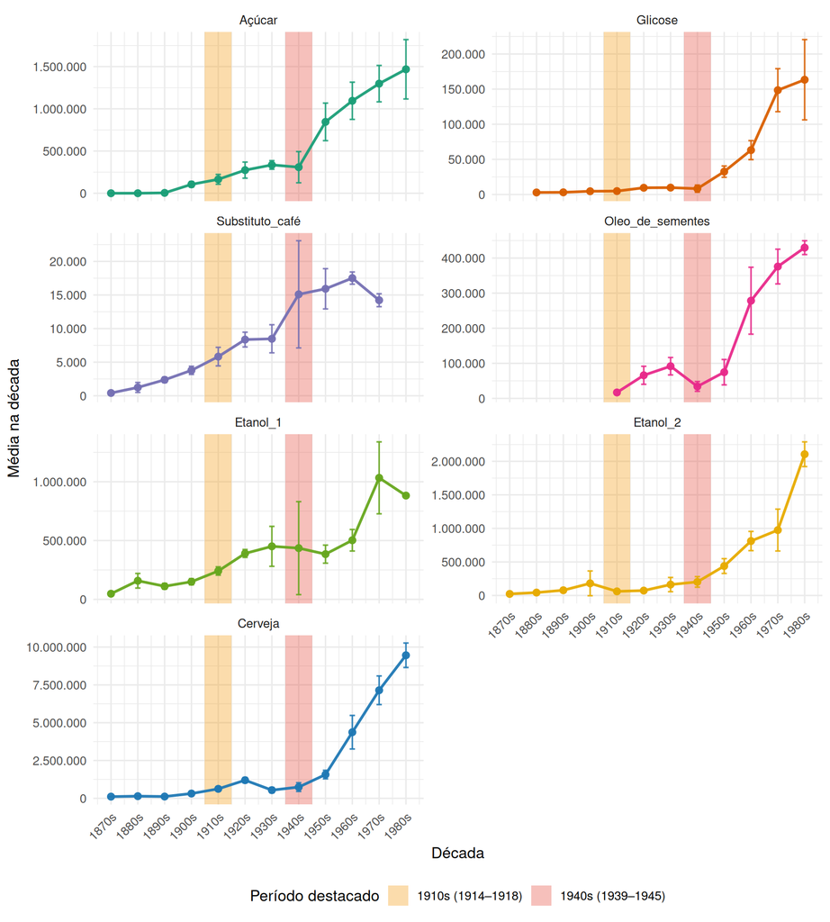

Figura 2: Média por década (± 1 DP) de cada produto, com destaque para as décadas das duas guerras mundiais.

```r
faixas_guerra <- tibble(
  xmin   = c(1910, 1940) - 5,
  xmax   = c(1910, 1940) + 5,
  guerra = c("1910s (1914–1918)", "1940s (1939–1945)")
)

eixo_x <- sort(unique(dados_decada$decada_num))

dd <- dados_decada |>
  mutate(Variavel = factor(Variavel, levels = variaveis_prod))

ggplot() +
  geom_rect(data = faixas_guerra,
            aes(xmin = xmin, xmax = xmax, ymin = -Inf, ymax = Inf, fill = guerra),
            alpha = 0.35, inherit.aes = FALSE) +
  geom_errorbar(data = dd,
                aes(x = decada_num, ymin = inferior, ymax = superior, color = Variavel),
                width = 2, linewidth = 0.6, alpha = 0.85) +
  geom_line(data = dd,
            aes(x = decada_num, y = valor_decada, color = Variavel, group = Variavel),
            linewidth = 1, alpha = 0.95) +
  geom_point(data = dd,
             aes(x = decada_num, y = valor_decada, color = Variavel),
             size = 2.2, alpha = 0.95) +
  facet_wrap(~ Variavel, scales = "free_y", ncol = 2) +
  scale_color_manual(values = paleta_produtos, guide = "none", drop = FALSE) +
  scale_fill_manual(
    values = c("1910s (1914–1918)" = "#f39c12", "1940s (1939–1945)" = "#e74c3c"),
    name = "Período destacado"
  ) +
  scale_x_continuous(breaks = eixo_x, labels = paste0(eixo_x, "s")) +
  scale_y_continuous(labels = label_number(big.mark = ".", decimal.mark = ",")) +
  labs(x = "Década", y = "Média na década") +
  theme(axis.text.x = element_text(angle = 45, hjust = 1),
        legend.position = "bottom")
```

Destaca-se, no período da 2ª Guerra, a variação na produção de açúcar, `etanol_1` e `substituto_café`, o que pode ser explicado pela necessidade de produzir outros materiais de maior prioridade durante um período de guerra. Na classificação HS 2017, o álcool etílico (`etanol_1` e `etanol_2`) é identificado com dois códigos diferentes (2207.10 e 2208.90), e a diferença é dada pelo teor alcoólico em volume (Alonzi; Ambroselli; Valery, 2020).

**Ver código**

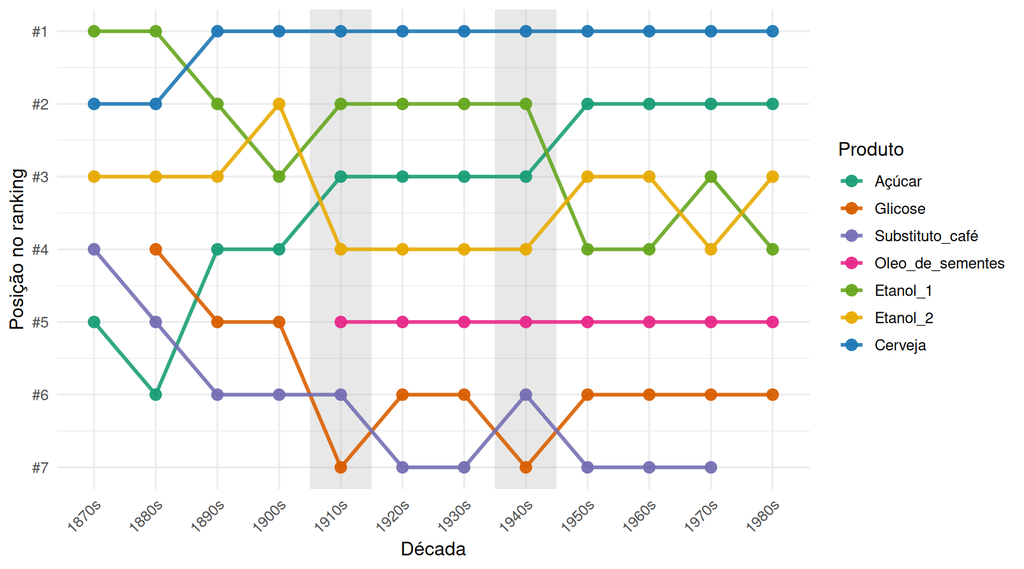

Figura 3: Ranking por década: posição de cada produto segundo o total produzido na década (valores brutos). As faixas cinza marcam as décadas de 1910 e 1940.

```r
rk <- comidas_bebidas_longer |>
  filter(!is.na(Valor), !is.na(Decada)) |>
  group_by(Decada, Variavel, unidade) |>
  summarise(total_decada = sum(Valor, na.rm = TRUE), .groups = "drop") |>
  group_by(Decada) |>
  mutate(posicao = rank(desc(total_decada), ties.method = "min")) |>
  ungroup() |>
  mutate(
    Decada   = factor(Decada, levels = decadas),
    Variavel = factor(Variavel, levels = variaveis_prod)
  )

n_prod <- length(variaveis_prod)

# faixas das décadas de guerra (posições no eixo discreto)
pos_guerra <- match(c("1910s", "1940s"), decadas)
faixas_rk  <- tibble(xmin = pos_guerra - 0.5, xmax = pos_guerra + 0.5) |>
  filter(!is.na(xmin))

ggplot(rk, aes(x = Decada, y = posicao, color = Variavel, group = Variavel)) +
  geom_rect(data = faixas_rk,
            aes(xmin = xmin, xmax = xmax, ymin = -Inf, ymax = Inf),
            fill = "grey70", alpha = 0.3, inherit.aes = FALSE) +
  geom_line(linewidth = 1.1, alpha = 0.9) +
  geom_point(size = 3, alpha = 0.95) +
  scale_y_reverse(breaks = seq_len(n_prod), labels = paste0("#", seq_len(n_prod))) +
  scale_color_manual(values = paleta_produtos, name = "Produto", drop = FALSE) +
  labs(x = "Década", y = "Posição no ranking") +
  theme(axis.text.x = element_text(angle = 45, hjust = 1),
        legend.position = "right")
```

# 4 Conclusão

Como trabalhos futuros, recomenda-se explorar a granularidade anual em torno dos conflitos e complementar a análise com variáveis econômicas e históricas do período.

**NotaDeclaração de Uso de Inteligência Artificial**

Este trabalho utilizou ferramentas de inteligência artificial (IA) como auxílio no processo de elaboração. Especificamente, o assistente Claude (Anthropic) foi utilizado para adaptar o texto e o código do projeto ao modelo de relatório da disciplina. Todas as análises estatísticas, interpretações dos resultados e conclusões são de responsabilidade exclusiva dos autores. O uso de IA foi restrito ao apoio na escrita, na formatação e na organização do código, não na condução das análises. Os autores declaram que revisaram criticamente todo o conteúdo gerado com auxílio de IA.

# Referências

**100 Data Visualization Project**. [*s. d.*]. Disponível em: <https://100.datavizproject.com/>. Acesso em: 22 nov. 2026

ALONZI, Francesca; AMBROSELLI, Simone; VALERY, Alberto. [COVID-19 emergency: a comprehensive overview of the economic classification systems for the manufacturing industry](https://istat.it). **Rivista di statistica ufficiale**. n. 3, 2020

CHANG, Winston; BORGES RIBEIRO, Barbara. **[shinydashboard: Create Dashboards with ’Shiny’](https://doi.org/10.32614/CRAN.package.shinydashboard)**. [*sine loco*: *sine nomine*]

INC., Plotly Technologies. **Collaborative data science**. Montreal, QC. Plotly Technologies Inc., 2015. Disponível em: <https://plot.ly>

PLOTLY. **Time Series and Date Axes in ggplot2**. [*s. d.*]. Disponível em: <https://plotly.com/ggplot2/time-series/>. Acesso em: 22 nov. 2026

POSIT / RSTUDIO. **shinydashboard: Get Started**. [*s. d.*]. Disponível em: <https://rstudio.github.io/shinydashboard/get_started.html>. Acesso em: 22 nov. 2026

R-BLOGGERS. **How to draw a heatmap in R — quick and easy way**. maio 2022. Disponível em: <https://www.r-bloggers.com/2022/05/how-to-draw-heatmap-in-r-quick-and-easy-way/>. Acesso em: 22 nov. 2026

THE R GRAPH GALLERY. **Levelplot with lattice**. [*s. d.*]. Disponível em: <https://r-graph-gallery.com/27-levelplot-with-lattice>. Acesso em: 22 nov. 2026

WICKHAM, Hadley; GROLEMUND, Garrett. **R for Data Science: Import, Tidy, Transform, Visualize, and Model Data**. [*s. l.*]: O’Reilly Media, 2017

ZAMAGNI, Vera. [Italy: how to lose the war and win the peace](https://doi.org/10.1017/CBO9780511523632.006). *In*: HARRISON, Mark (Org.). **The Economics of World War II: Six Great Powers in International Comparison**. Cambridge: Cambridge University Press, 1998. p. 192–197.